# NewsPresentationStats

Lisa Matthias

25 9 2023

```
## function (...)
## .Internal(options(...))
## <bytecode: 0x000000001376c660>
## <environment: namespace:base>
```

## Presence of Emotional Appeals

This compares robust samples of news mentions between channel types and time periods and checks whether the share of news mentions with emotional appeals present/absent is comparable between them.

### Network News Time Periods

This compares network news mentions from the 1990-1999 and 2000-2018 terms.

```r
#Robust with identical mentions left out
#Chi-Squared for pre-2000 and post-2000 network news ~ emotion
chisq_emo_time_robust <- function_chisq_emo_pre2000(mntn_emo_robust, news_var = "ChannelTypeSplit", var = "EmotionPresent")

chisq_emo_time_robust
```

```
Pearson's Chi-squared test
```

data: . X-squared = 0.003, df = 1, p-value = 1

### Channel Type

This compares network and cable news mentions from the 2000-2018 terms.

```r
#Chi-Squared for post-2000 network news and cable news ~ emotion
chisq_emo_channel_robust <- function_chisq_emo_post2000(mntn_emo_robust, news_var = "ChannelTypeSplit", var = "EmotionPresent")

chisq_emo_channel_robust
```

```
Pearson's Chi-squared test
```

data: . X-squared = 0.09, df = 1, p-value = 0.8

### Cable News Program

This compares Hardball (MSNBC) and Special Report (Fox News) news mentions from the 2000-2018 terms.

```r
#Chi-Squared for Hardball and Special Report ~ emotion
chisq_emo_cable_robust <- function_chisq_emo_cable(mntn_emo_robust, news_var = "NewsProgram", var = "EmotionPresent")

chisq_emo_cable_robust
```

```
Pearson's Chi-squared test
```

data: . X-squared = 4, df = 1, p-value = 0.06

```r
chisq_emo_cable_robust_results <- consolidate_chisq_results(chisq_emo_cable_robust, context_col = "Present") %>%
  group_by(Present) %>%
  gt() %>%
  tab_style(
    style = cell_text(weight = "bold"),
    locations = cells_row_groups())

chisq_emo_cable_robust_results
```

| NewsProgram | Observed | Expected | StdRes |
| --- | --- | --- | --- |
| No |  |  |  |
| Hardball | 24 | 29.7 | -1.88 |
| SpecialReport | 43 | 37.3 | 1.88 |
| Yes |  |  |  |
| Hardball | 42 | 36.3 | 1.88 |
| SpecialReport | 40 | 45.7 | -1.88 |

### Not Robust

This is just to show the results with the full sample.

**First the network news time periods.**

```r
#Chi-Squared for pre-2000 and post-2000 network news ~ emotion
chisq_emo_time_unfiltered <- function_chisq_emo_pre2000(mntn_emo, news_var = "ChannelTypeSplit", var = "EmotionPresent")

chisq_emo_time_unfiltered
```

```
Pearson's Chi-squared test
```

data: . X-squared = 2, df = 1, p-value = 0.1

**Then network and cable news, 2000-2018 terms.**

```r
#Chi-Squared for post-2000 network news and cable news ~ emotion
chisq_emo_channel_unfiltered <- function_chisq_emo_post2000(mntn_emo, news_var = "ChannelTypeSplit", var = "EmotionPresent")

chisq_emo_channel_unfiltered
```

```
Pearson's Chi-squared test
```

data: . X-squared = 2e-04, df = 1, p-value = 1

**And the cable programs.**

```r
#Chi-Squared for Hardball and Special Report ~ emotion
chisq_emo_cable_unfiltered <- function_chisq_emo_cable(mntn_emo, news_var = "NewsProgram", var = "EmotionPresent")

chisq_emo_cable_unfiltered
```

```
Pearson's Chi-squared test
```

data: . X-squared = 8, df = 1, p-value = 0.005

## Type of Emotional Appeals

This compares news samples based on the share of positive/negative emotional appeals included in the news mentions as well as the distinct emotions featured most frequently.

### Network News Time Period

This compares network news mentions from the 1990-1999 and 2000-2018 terms.

```r
contingency_emo_type_channels_robust <- mntn_emo_robust %>%
  filter(EmotionPresent == "1") %>%
  group_by(ChannelTypeSplit) %>%
  summarise(NegativeEmotion = sum(NegativeEmotion, na.rm = TRUE),
            PositiveEmotion = sum(PositiveEmotion, na.rm = TRUE)) %>%
  as_tabyl()

chisq_emo_type_time_robust <- contingency_emo_type_channels_robust %>%
  filter(ChannelTypeSplit != "CableNews") %>%
  janitor::chisq.test(correct = FALSE)

chisq_emo_type_time_robust
```

```
Pearson's Chi-squared test
```

data: . X-squared = 15, df = 1, p-value = 1e-04

### Channel Type

This compares network and cable news mentions from the 2000-2018 terms.

```r
chisq_emo_type_channel_robust <- contingency_emo_type_channels_robust %>%
  filter(ChannelTypeSplit != "NetworkNewsPre2000") %>%
  janitor::chisq.test(correct = FALSE)

chisq_emo_type_channel_robust
```

```
Pearson's Chi-squared test
```

data: . X-squared = 3, df = 1, p-value = 0.1

### Cable News Programs

This compares Hardball (MSNBC) and Special Report (Fox News) news mentions from the 2000-2018 terms.

```r
contingency_emo_type_cable_robust <- mntn_emo_robust %>%
  filter(EmotionPresent == "1") %>%
  group_by(NewsProgram) %>%
  summarise(NegativeEmotion = sum(NegativeEmotion, na.rm = TRUE),
            PositiveEmotion = sum(PositiveEmotion, na.rm = TRUE)) %>%
  as_tabyl()

chisq_emo_type_cable_robust <- contingency_emo_type_cable_robust %>%
  filter(NewsProgram != "WorldNewsTonight") %>%
  janitor::chisq.test(correct = FALSE)

chisq_emo_type_cable_robust
```

```
Pearson's Chi-squared test
```

data: . X-squared = 31, df = 1, p-value = 2e-08

```r
chisq_emo_type_cable_robust_results <- consolidate_chisq_results(chisq_emo_type_cable_robust, context_col = "EmotionType") %>%
  group_by(EmotionType) %>%
  gt() %>%
  tab_style(
    style = cell_text(weight = "bold"),
    locations = cells_row_groups()) %>%
  tab_footnote(
  footnote = "A = Hardball; B = Special Report"
)

chisq_emo_type_cable_robust_results
```

| NewsProgram | Observed | Expected | StdRes |
| --- | --- | --- | --- |
| NegativeEmotion |  |  |  |
| A | 196 | 225.2 | -5.61 |
| B | 189 | 159.8 | 5.61 |
| PositiveEmotion |  |  |  |
| A | 121 | 91.8 | 5.61 |
| B | 36 | 65.2 | -5.61 |

A = Hardball; B = Special Report

## Most Frequently Used Emotions

### Channel Type and Time Period, Top 3.

```r
top3_emo_channel <- mntn_emo_robust %>%
  select(ChannelTypeSplit, NegativeEmotionAlarming:PositiveEmotionThing) %>%
  group_by(ChannelTypeSplit) %>%
summarise(across(everything(), list(sum))) %>%
  group_by(ChannelTypeSplit) %>%
  pivot_longer(cols = NegativeEmotionAlarming_1:PositiveEmotionThing_1,
               names_to = "EmotionTypeSpec",
               values_to = "n") %>%
  arrange(desc(n)) %>%
  slice(1:3)

top3_emo_channel_results <- top3_emo_channel %>%
  group_by(ChannelTypeSplit) %>%
  gt() %>%
  tab_style(
    style = cell_text(weight = "bold"),
    locations = cells_row_groups())

top3_emo_channel_results
```

| EmotionTypeSpec | n |
| --- | --- |
| NetworkNewsPre2000 |  |
| NegativeEmotionDimensionGeneral_1 | 18 |
| NegativeEmotionFear_1 | 11 |
| NegativeAnger_1 | 5 |
| NetworkNewsPost2000 |  |
| NegativeEmotionDimensionGeneral_1 | 7 |
| NegativeEmotionFear_1 | 7 |
| PositiveEmotionDimensionGeneral_1 | 5 |
| CableNews |  |
| NegativeEmotionDimensionGeneral_1 | 189 |
| PositiveEmotionDimensionGeneral_1 | 91 |
| NegativeEmotionFear_1 | 49 |
| NA |  |
| NegativeEmotionAlarming_1 | NA |
| NegativeAnger_1 | NA |
| NegativeEmotionAnguish_1 | NA |

### Cable News Program, Top 3.

```r
top3_emo_cable <- mntn_emo_robust %>%
  filter(ChannelTypeSplit == "CableNews") %>%
  select(NewsProgram, NegativeEmotionAlarming:PositiveEmotionThing) %>%
  group_by(NewsProgram) %>%
summarise(across(everything(), list(sum))) %>%
  group_by(NewsProgram) %>%
  pivot_longer(cols = NegativeEmotionAlarming_1:PositiveEmotionThing_1,
               names_to = "EmotionTypeSpec",
               values_to = "n") %>%
  arrange(desc(n)) %>%
  slice(1:3)

top3_emo_cable_results <- top3_emo_cable %>%
  group_by(NewsProgram) %>%
  gt() %>%
  tab_style(
    style = cell_text(weight = "bold"),
    locations = cells_row_groups())

top3_emo_cable_results
```

| EmotionTypeSpec | n |
| --- | --- |
| Hardball |  |
| NegativeEmotionDimensionGeneral_1 | 105 |
| PositiveEmotionDimensionGeneral_1 | 73 |
| NegativeEmotionFear_1 | 21 |
| SpecialReport |  |
| NegativeEmotionDimensionGeneral_1 | 84 |
| NegativeEmotionFear_1 | 28 |
| PositiveEmotionDimensionGeneral_1 | 18 |

## Does the amount of emotional appeals differ between issue areas?

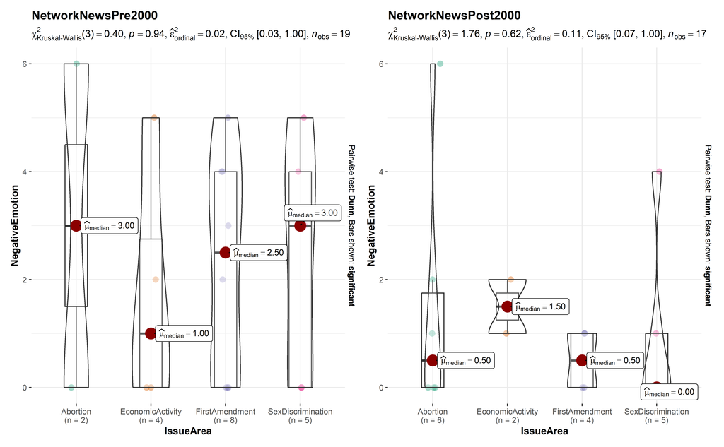

```r
# ggstatsplot for quick overview
violin_channel_neg_issue <-
mntn_emo_robust %>%
  filter(ChannelTypeSplit != "NetworkNewsPre2000") %>%
ggstatsplot::grouped_ggbetweenstats(x = IssueArea, y = NegativeEmotion, grouping.var = ChannelTypeSplit, type = "np")

violin_network_neg_issue <-
mntn_emo_robust %>%
  filter(ChannelTypeSplit != "CableNews") %>%
ggstatsplot::grouped_ggbetweenstats(x = IssueArea, y = NegativeEmotion, grouping.var = ChannelTypeSplit, type = "np")

violin_cable_neg_issue <-
mntn_emo_robust %>%
  filter(NewsProgram != "WorldNewsTonight") %>%
ggstatsplot::grouped_ggbetweenstats(x = IssueArea, y = NegativeEmotion, grouping.var = NewsProgram, type = "np")

violin_network_neg_issue
```

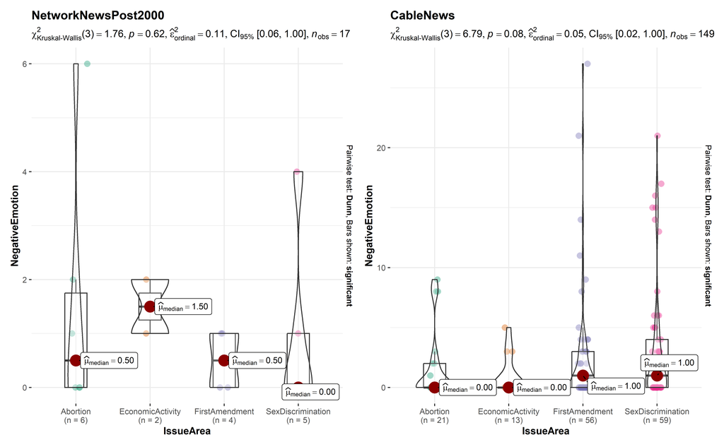

```r
violin_channel_neg_issue
```

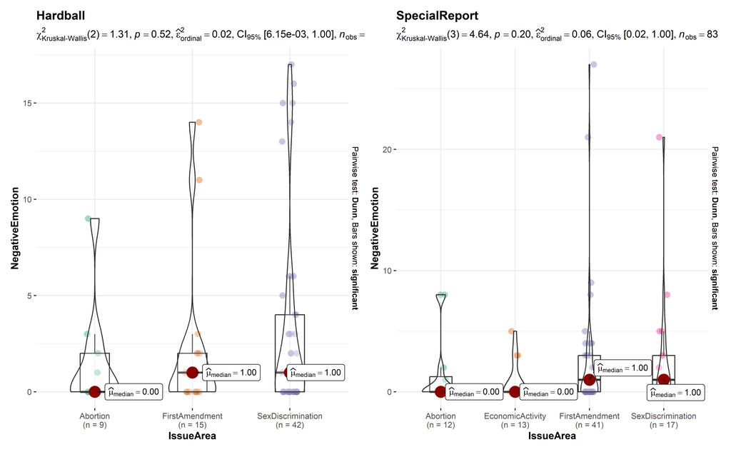

```r
violin_cable_neg_issue
```